# Multinomiale logistische Regression

Dieser Beitrag wurde zuerst auf https://borisls.github.io/ veröfentlicht.

In dem letzten [Beitrag](https://borisls.github.io/blog/logregression.html) wurde die dichotome logistische Regression als ein mögliches Klassifikationsverfahren vorgestellt. Hierbei wurde versucht zwischen den erklärenden Variablen (*features*) und der dichotomen abhängigen Variable `y.class` ein Zusammenhang zu modellieren. *Dichotom* bedeutete dabei, dass die abhängige Variable nur zwei Ausprägungen haben konnte. Wenn die abhängige Variable mehr als zwei Ausprägungen besitzen kann, dann wird von einem multinomialen Klassifierungsproblem gesprochen. In diesem Beitrag wird ein mögliches Vorgehen zur Lösung dieser Aufgabenstellung in **R** mit der [multinomialen logistischen Regression](https://de.wikipedia.org/wiki/Multinomiale_logistische_Regression) vorgestellt. Das Vorgehen wird *one-vs-all* oder *one-vs-rest* genannt.

Die Strategie besteht darin, einen logistisches Regressionsmodell pro Klasse schätze. Dazu wird das Schätzproblem jeweils in ein dichotomes Schätzproblem überführt (Klasse vs. Nicht-Klasse). Im Anschluss wird diejenige Klasse zugewiesen, die die höchste Wahrscheinlichkeit für ein Zurodnung besitzt.

### Darstellung des Klassifizierungsproblems

Im ersten Schritt wird ein Klassifizierungsproblem erstellt. Hierfür werden der *features* `f1` und `f2` in der Designmatrix `design.mx` erzeugt. Anschließend wird die Variable `y` als Linearkombination dieser zwei *features* erzeugt. Die Zielvariable `y.class` des multinomialen Klassifizierungsproblems wird aus `y` abgeleitet. Die grafische Darstellung des Klassifizierungsproblems erfolgt mit der aus dem vorherigen [Beitrag](https://borisls.github.io/blog/logregression.html) bekannten Funktion `plot.classification`.

```r
set.seed(08112016)
m <- 10000

design.mx <- data.frame(f1=runif(m, -1, 1),
                        f2=runif(m, -1, 1))

y = as.matrix(design.mx) %*% c(1,1)

y.class <- 1
y.class <- ifelse(y > quantile(y, 0.8), 2, y.class)
y.class <- ifelse(y < quantile(y, 0.5), 3, y.class)
y.class <- ifelse(design.mx[,2] < -0.5, 4, y.class)
```

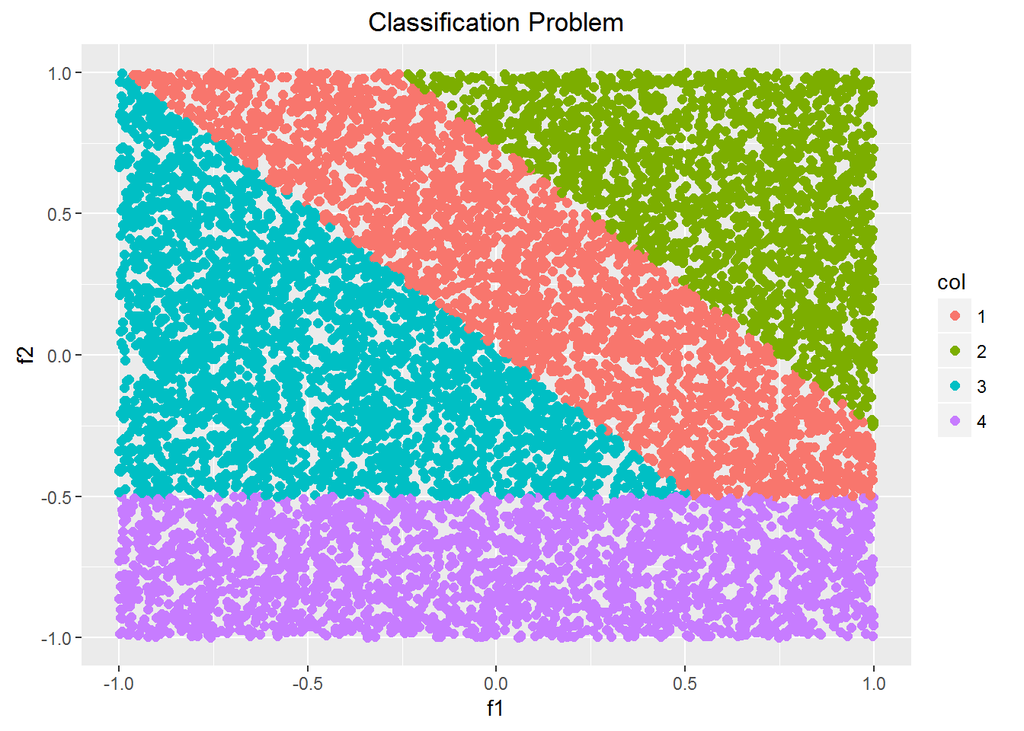

### Training der Klassifizierungsmodelle für jede Klasse

Für die Schätzung der einzelnen logistischen Regressionsmodelle ist die Datenbasis in Abhängigkeit der Klasse zu modellieren. Hierfür wird die Hilfsfunktion `createOneAllData` verwendet. Sie ergänzt die Beobachtungen der Designmatrix um eine weitere Spalte `y.mod`. Diese Spalte besitzt die Ausprägung 1, wenn die Beobachtung `y` mit der Klasse `x` übereinstimmt. Sie besitzt die Ausprägung 0, wenn es eine andere Klasse besitzt (*one-vs-all*).

```r
create.OneAllData <- function(df, x, y){

  data.glm <- df %>%
              mutate(y.mod = ifelse(y == x, 1, 0))

  return(data.glm)
}
```

Im nächsten Schritt wird diese Funktion für jede Ausprägung von `y.class` angewendet. Das Ergebnis für jede Klasse dient als Input für die Schätzung der logistischen Regressionsmodelle pro Klasse mit der Funktion `glm`. Die sich hieraus ergebenden logistische Regressionsmodelle werden in der Liste `model.ls` abgespeichert. Werden die einzelnen Regressionsmodelle in einer Liste abgespeichert, so können diese später mit der `apply`-Funktion sehr gut weiter verwendet werden.

```r
uni.cl <- unique(y.class)
model.ls <- vector("list", length(uni.cl))
names(model.ls) <- paste0("Class_", seq_along(uni.cl))

for(i in seq_along(uni.cl)){

  data.glm <- create.OneAllData(df=design.mx, x=i, y=y.class)

  model.ls[[i]] <- glm(y.mod ~ f1 + f2,
                       data=data.glm,
                       family=binomial())
}
```

Folgende Regressionskoeffizienten ergeben sich für die einzelnen Modelle pro Klasse.

```r
lapply(model.ls, coef)
```

```
## $Class_1
## (Intercept)          f1          f2
##  -1.1246382   0.4526899   1.1518830
##
## $Class_2
## (Intercept)          f1          f2
##   -45745.80    61479.79    61494.13
##
## $Class_3
## (Intercept)          f1          f2
## -1.37145942 -2.81248800  0.00695539
##
## $Class_4
##   (Intercept)            f1            f2
## -2.197455e+04 -3.696179e-01 -4.394713e+04
```

### Zuweisung der Klassen auf Basis der geschätzten One-vs-All-Modelle

Im nächsten Schritt ist jedes geschätzte Regressionsmodell auf die Beobachtungen anzuwenden. Anschließend kann ermittelt werden, welches Regressionsmodell zu der einzelnen Beobachtung die höchste Wahrscheinlichkeit für eine Klase liefert.

Hierfür wird die Hilfsfunktion `predict.Modell` benötigt, die ein gegebenes Regressionsmodell auf eine Designmatrix anwendet.

```r
predict.Model <- function(Model, df = design.mx){

  r <- predict(Model,
               newdata = df,
               type="response")

  return(r)
}
```

Diese Funktion wird nun auf jedes geschätzte Regressionsmodell in `model.ls` angewendet.Hierfür wird die `lapply`-Funktion verwendet. Das Ergebnis ist das Dataframe `pre.df`

```r
pre.df <- as.data.frame((lapply(model.ls, predict.Model)))
```

Exemplarisch werden die ersten Zeilen des Dataframes `pre.df` dargestellt.

| Class_1 | Class_2 | Class_3 | Class_4 |
| --- | --- | --- | --- |
| 0.1836 | 0 | 0.3711 | 0 |
| 0.2310 | 0 | 0.2011 | 0 |
| 0.3758 | 0 | 0.4938 | 0 |
| 0.5047 | 1 | 0.0185 | 0 |
| 0.1369 | 0 | 0.0493 | 1 |
| 0.3661 | 1 | 0.0239 | 0 |

Nachdem die Wahrscheinlichkeit für das Auftreten in jeder Klasse ermittelt worden ist, muss noch identifizeirt werden, welches Regressionsmodell die höchste Wahrscheinlichkeit liefert. Dies erfolgt wiederum mit der `apply`-Funktion in Verbinund mit `which.max`.

```r
pre.df$Class.Model.Ind <- apply(pre.df,1,which.max)
pre.df$Class.Model <- colnames(pre.df)[pre.df$Class.Model.Ind]
```

Exemplarisch dargestellt für die ersten Beobachtungen ergibt sich somit folgende Zuteilung zu den Klassen.

| Class_1 | Class_2 | Class_3 | Class_4 | Class.Model.Ind | Class.Model |
| --- | --- | --- | --- | --- | --- |
| 0.1836 | 0 | 0.3711 | 0 | 3 | Class_3 |
| 0.2310 | 0 | 0.2011 | 0 | 1 | Class_1 |
| 0.3758 | 0 | 0.4938 | 0 | 3 | Class_3 |
| 0.5047 | 1 | 0.0185 | 0 | 2 | Class_2 |
| 0.1369 | 0 | 0.0493 | 1 | 4 | Class_4 |
| 0.3661 | 1 | 0.0239 | 0 | 2 | Class_2 |

### Modellanalyse

Die Modellanalyse ist jedoch ernüchternd. Die Ergebnisdarstellung und die Konfusionsmatrix zeigen, dass die Klassen 1 und 3 nicht zufriedendstellend durch dieses Vorgehen voneinander getrennt wurden.

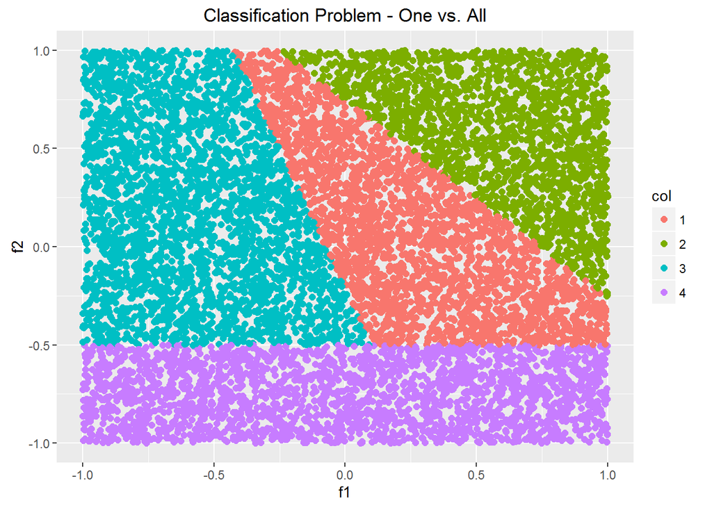

|  | Predicted_Class_1 | Predicted_Class_2 | Predicted_Class_3 | Predicted_Class_4 |
| --- | --- | --- | --- | --- |
| Actual_Class_1 | 2101 | 0 | 585 | 0 |
| Actual_Class_2 | 0 | 2000 | 0 | 0 |
| Actual_Class_3 | 369 | 0 | 2515 | 0 |
| Actual_Class_4 | 0 | 0 | 0 | 2430 |

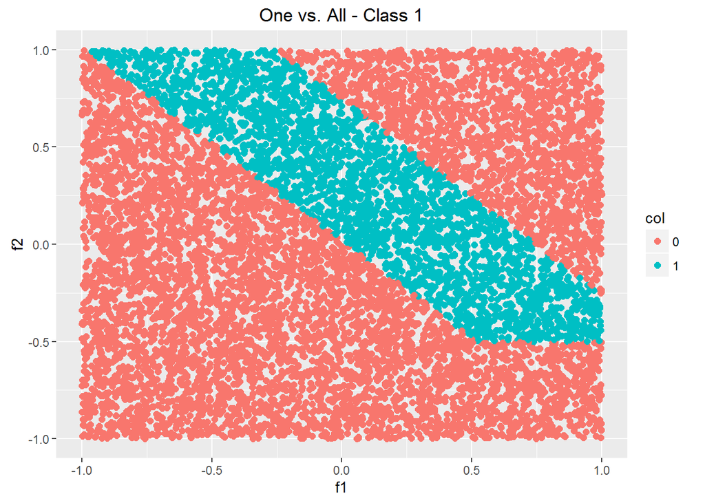

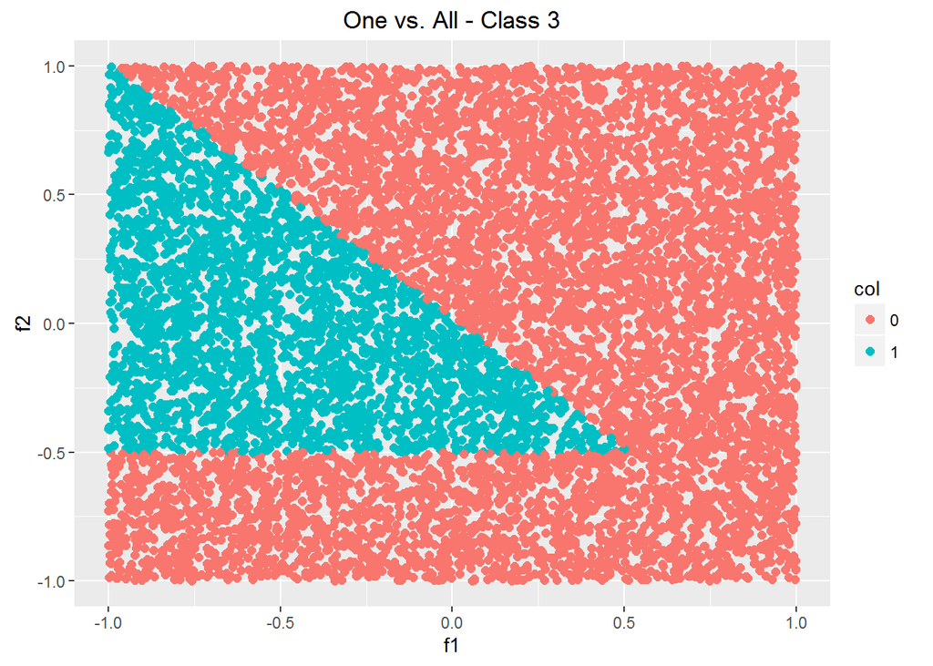

### Modellerweiterung

Zur Verbesserung der Klassifizierung könnte man die einzelnen One-vs-All-Modell um die Terme der 2. Ordnung als erklärende Variablen erweitern. Das Ergebnis des erweiterten Vorgehens ist besser, jedoch besitzt jedoch weiter Schwächen.

```r
for(i in seq_along(uni.cl)){

  data.glm <- create.OneAllData(df=design.mx, x=i, y=y.class)

  model.ls[[i]] <- glm(y.mod ~ f1 + f2 + f1*f2 + f1*f1 + f2*f2,
                       data=data.glm,
                       family=binomial())
}

pre.df <- as.data.frame((lapply(model.ls, predict.Model)))
pre.df$Class.Model.Ind <- apply(pre.df,1,which.max)
pre.df$Class.Model <- colnames(pre.df)[pre.df$Class.Model.Ind]
```

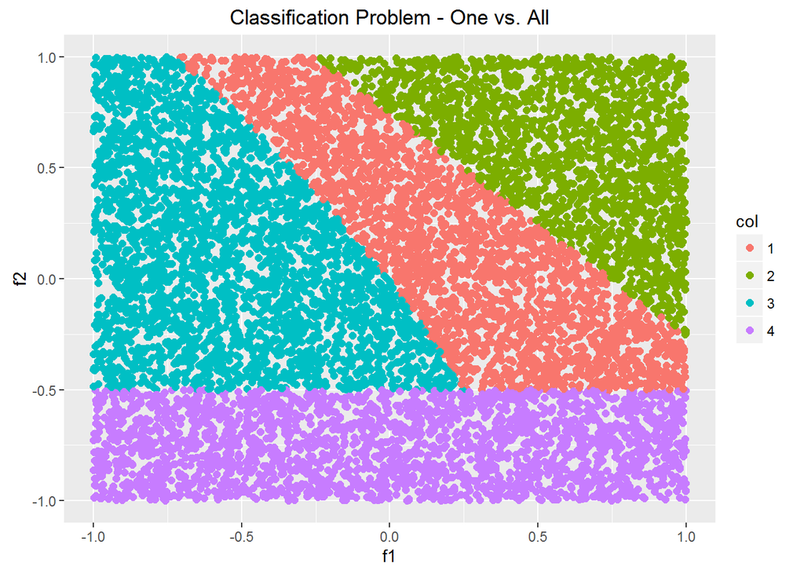

|  | Predicted_Class_1 | Predicted_Class_2 | Predicted_Class_3 | Predicted_Class_4 |
| --- | --- | --- | --- | --- |
| Actual_Class_1 | 2315 | 0 | 371 | 0 |
| Actual_Class_2 | 0 | 2000 | 0 | 0 |
| Actual_Class_3 | 184 | 0 | 2700 | 0 |
| Actual_Class_4 | 0 | 0 | 0 | 2430 |

### Verwendung der `multinom`-Funktion

Nachfolgend wird die `multinom`-Funktion aus dem [nnet-Package](https://cran.r-project.org/web/packages/nnet/) verwendet, um ein multinomiales logistisches Regressionsmodell abzuschätzen.

```r
library(nnet)
```

Die `multinom`-Funktion verwendet für die Modellschätzung ein Neuronales Netz.

```r
data.glm <- design.mx %>%
            mutate(y.mod = y.class)

model.glm <- multinom(y.mod ~ f1 + f2,
                     data = data.glm)
y.mlg <- predict(model.glm,
             newdata = data.glm)
```

Die Modellanalyse zeigt, dass die `multinom`-Funktion deutlich bessere Ergebnisse für das obige Klassifizierungsproblem liefert, als das selbstgebaute Vorgehen.

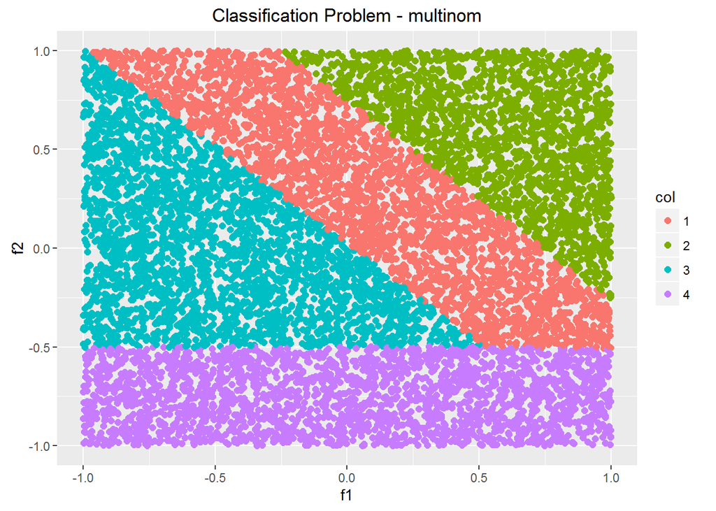

|  | Predicted_Class_1 | Predicted_Class_2 | Predicted_Class_3 | Predicted_Class_4 |
| --- | --- | --- | --- | --- |
| Actual_Class_1 | 2679 | 1 | 5 | 1 |
| Actual_Class_2 | 0 | 2000 | 0 | 0 |
| Actual_Class_3 | 2 | 0 | 2877 | 5 |
| Actual_Class_4 | 4 | 0 | 2 | 2424 |